# NSW Road Crash Severity Prediction

#### 6.2 Decision Tree - Improvement

To optimize the Decision Tree, Cost-Complexity Pruning was applied to control the tree’s depth and mitigate overfitting. The baseline model was artificially constrained by the default complexity parameter (cp = 0.01). To determine the true optimal architecture, a deeper tree was initially grown with a relaxed threshold (cp = 0.001), and the cross-validation error (xerror) was tracked across varying tree sizes. Minimization of the xerror identified an optimal split threshold of cp = 0.00115.

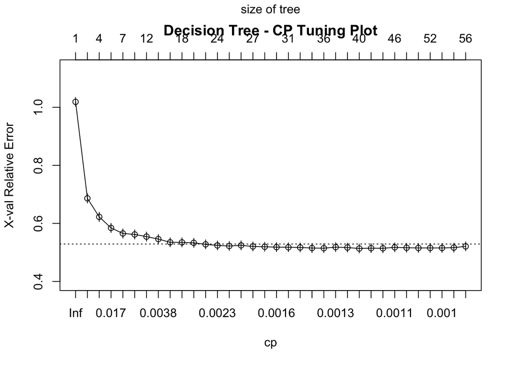

```r
# Decision Tree improvement  -  tune complexity by pruning via CP table
set.seed(42)

# 1. First grow a deeper tree (relax the cp parameter to 0.001) to find the optimal split points
model_dt_deep <- rpart(
  Degree.of.crash ~ .,
  data = train_dt,
  method = "class",
  weights = dt_weights,
  control = rpart.control(cp = 0.001, xval = 5) # xval=5 保持与小组统一定义的 5-fold CV 一致
)

# 2. Extract the CP with minimum xerror from the deep tree
best_cp <- model_dt_deep$cptable[which.min(model_dt_deep$cptable[, "xerror"]), "CP"]
cat("Best cp from xerror minimisation:", best_cp, "\n")

# 3. Plot and save CP tuning graph
png("plots/6_2_decision_tree_cp_plot.png", width = 1000, height = 700, res = 150)
plotcp(model_dt_deep, main = "Decision Tree - CP Tuning Plot")
text(x = best_cp, y = min(model_dt_deep$cptable[, "xerror"]), labels = paste("best cp =", signif(best_cp, 3)), pos = 4, cex = 0.8)
invisible(dev.off())

plotcp(model_dt_deep, main = "Decision Tree - CP Tuning Plot")
```

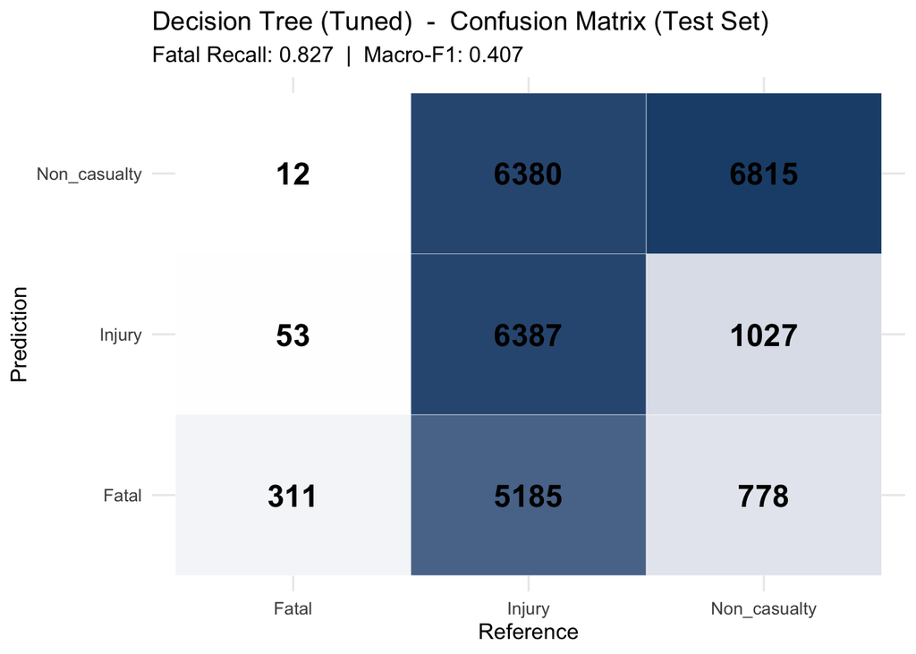

```r
# 4. 用找到的最优 CP 对深树进行剪枝
model_dt_tuned <- prune(model_dt_deep, cp = best_cp)

# 5. 在测试集上评估剪枝后的模型
pred_dt_tuned <- predict(model_dt_tuned, newdata = test_dt, type = "class")
cm_dt_tuned <- confusionMatrix(pred_dt_tuned, test_dt$Degree.of.crash)

fatal_recall_dt_tuned <- as.numeric(cm_dt_tuned$byClass["Class: Fatal", "Recall"])
f1_dt_tuned_vec <- setNames(cm_dt_tuned$byClass[, "F1"], gsub("Class: ", "", rownames(cm_dt_tuned$byClass)))
macro_f1_dt_tuned <- mean(f1_dt_tuned_vec, na.rm = TRUE)
weighted_f1_dt_tuned <- weighted.mean(f1_dt_tuned_vec[names(test_props_dt)], test_props_dt, na.rm = TRUE)
kappa_dt_tuned <- as.numeric(cm_dt_tuned$overall["Kappa"])

cat(sprintf(
  "   Decision Tree (Tuned)  -  Test Set Metrics\nMacro-F1     : %.4f\nFatal Recall : %.4f\nWeighted F1  : %.4f\nKappa        : %.4f\n",
  macro_f1_dt_tuned, fatal_recall_dt_tuned, weighted_f1_dt_tuned, kappa_dt_tuned
))

# 6. Generate Before/After comparison table
before_after_dt <- data.frame(
  Model = c("DT: default cp (0.01)", paste0("DT: tuned cp (", signif(best_cp, 3), ")")),
  `Macro-F1` = round(c(macro_f1_dt, macro_f1_dt_tuned), 4),
  `Fatal Recall` = round(c(fatal_recall_dt, fatal_recall_dt_tuned), 4),
  check.names = FALSE
)
knitr::kable(before_after_dt, caption = "Decision Tree  -  Before vs After Pruning")

# 7. Plot Tuned Confusion Matrix heatmap
p_dt_tuned_cm <- as.data.frame(cm_dt_tuned$table) %>%
  ggplot(aes(x = Reference, y = Prediction, fill = Freq)) +
  geom_tile(colour = "white") +
  geom_text(aes(label = Freq), size = 6, fontface = "bold") +
  scale_fill_gradient(low = "white", high = "#1F4E79") +
  labs(
    title = "Decision Tree (Tuned)  -  Confusion Matrix (Test Set)",
    subtitle = paste0("Fatal Recall: ", round(fatal_recall_dt_tuned, 3),
                      "  |  Macro-F1: ", round(macro_f1_dt_tuned, 3))
  ) +
  theme_minimal(base_size = 12) +
  theme(legend.position = "none")
print(p_dt_tuned_cm)
```

```r
ggsave("plots/6_2_decision_tree_tuned_confusion_matrix.png", p_dt_tuned_cm, width = 7, height = 5, dpi = 150)
```

[output not shown]

Decision Tree - Before vs After Pruning

| Model | Macro-F1 | Fatal Recall |
| --- | --- | --- |
| DT: default cp (0.01) | 0.4290 | 0.7287 |
| DT: tuned cp (0.00115) | 0.4068 | 0.8271 |

Evaluating this deeper, tuned tree on the test set revealed a significant divergence in performance: Fatal Recall surged to an impressive 0.8271, but the primary metric, Macro-F1, dropped from 0.4290 to 0.4068. This occurs because the deeper tree captures more granular, complex rules. When combined with the heavy inverse-frequency class weights used during training, the deeper tree became hyper-sensitive to the minority class. While this hyper-sensitivity successfully captured nearly 83% of all fatal crashes, it generated a disproportionate number of false positives (misclassifying severe injuries as fatal), which severely penalized overall precision. Because the project’s primary objective is to maximize Macro-F1 subject to a Fatal Recall $\geq$ 0.50, the shallower baseline model (cp = 0.01) is strictly preferred. It offers a more balanced decision boundary, achieving a higher Macro-F1 while comfortably satisfying the safety constraint.